# Part II - (Presentation of Loan Data from Prosper Exploration)

## by (Okaome Samson Maduabuchi)

## Investigation Overview

In this investigation, i attempted to study the features of a loan that could help determine the borrowers rate and loan status of the loan. my main focus was directed towards the prosper risk score , borrowers monthly income and the borrower employment status of as regards the loans.

## Dataset Overview

The data set used in this investigation contains 113,937 loans with 81 variables on each loan, including loan amount, borrower rate (or interest rate), current loan status, borrower income, and many others, but only 5 features were used due to their relevance to my analysis, while about 30,000 missing entries were dropped due to the fact that the data was collected before july £2009 which did not include data for prosper score ( a very important variable for my analysis) Note: The prosper score is a score used to scale loans based on how risky or less risky they are custom risk score built using historical Prosper data. The score ranges from 1-10, with 10 being the best, or lowest risk score. Applicable for loans originated after July 2009.

## Distribution of Borrowers rate

The distribution of borrowers rate shows that borrower rate ranges from 0.05(5%) to 0.35(35%) there is a spike(mode) in amount of loans at BorrowerRate just above 0.3(30%) and close to 0.32(32%)

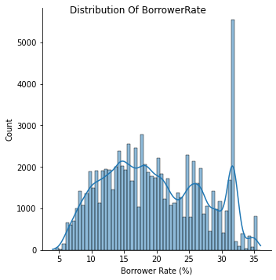

## Distribution of Prosper Score

The distribution of Prosper risk score shows that its values ranges from 1-11, with majority(the mode) of the Loan having a risk score of 4.0 which appears to be risky based on the scale of the prosper score, But moving down we would notice high counts at prosper score of 6.0,7.0 and 8.0 which indicates less risky loans

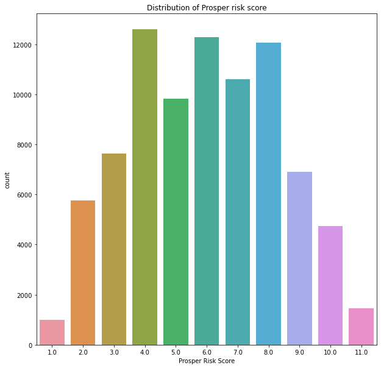

## Borrower Rate vs Prosper Risk Score

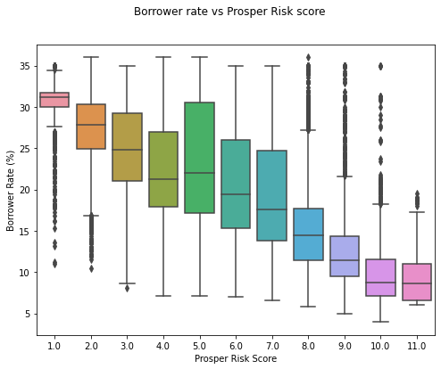

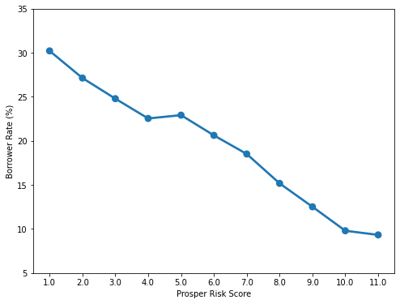

## Loan status vs Prosper risk score

Charged off loans and Past due loans appears to be more highly risky on an average with a risk score of 5, while current, defaulted and loans with final payments in progress, appears to be moderately risky with a risk score of 6 on an average and completed loans appears to be less risky on an average with a risk score of 7

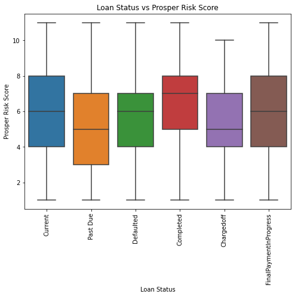

## Borrowers rate and Prosper Risk Score by Employment Status

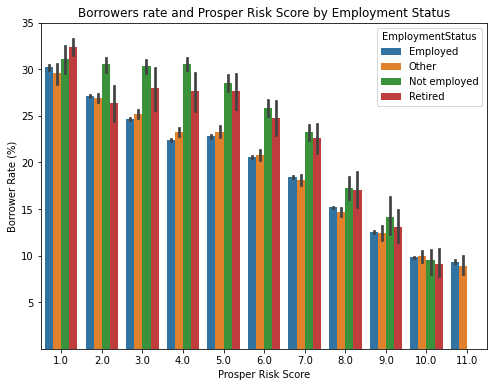

## Loan status, Prosper Risk Score , Employment Status

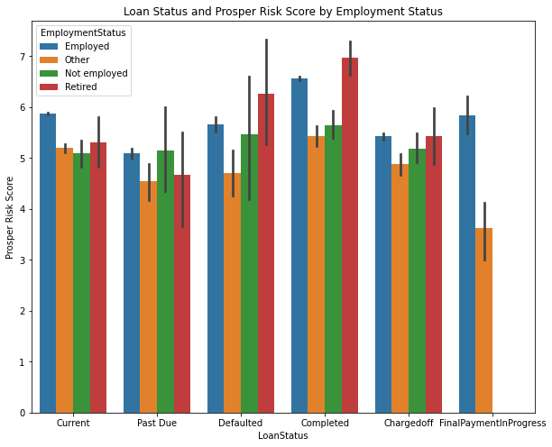